# Análise Multivariada

Bacharelado em Administração

Prof. Washington Santos da Silva

01/11/2023

# Modelos de Regressão Linear

> **“Essentially, all models are wrong, but some are useful”**.

George Box - Estatístico.

### Modelos de Regressão Linear

Considere os dados de publicidade mostrados no próximo slide.

Perguntas que podemos fazer:

- Existe uma relação entre o orçamento de publicidade e vendas?
- Quão forte é a relação entre o orçamento de publicidade e vendas?
- Quais mídias contribuem para as vendas?
- Com que precisão podemos prever as vendas futuras?
- A relação é linear?
- Existe sinergia entre as mídias publicitárias?

# Advertising Data

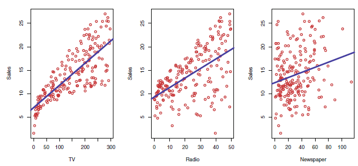

# Modelos/Análise de Regressão Linear

- A regressão é provavelmente a ferramenta mais importante à disposição do econometrista.
- Mas o que é a análise de regressão?
- Técnica estatística que busca descrever e avaliar a relação entre uma determinada variável (geralmente chamada de variável dependente, $\mathbf{y}$) e uma ou mais outras variáveis (geralmente conhecidas como variável(is) independente(s), $\mathbf{x}$).

# Modelos/Análise de Regressão Linear

Alguns nomes alternativos para $y$ e $x$:

[output not shown]

# Modelos de Regressão

- Variável Resposta = $Y$
  - Em modelos de regressão a variável resposta $Y$ é **aleatória, numérica e contínua**.
  - $Y$ pode ser numérica discreta ou categórica, mas devemos usar uma classe mais ampla de modelos (Modelos Lineares Generalizado).
- Variáveis Explicativas/Preditoras = $X_1,X_2,\ldots,X_k$
  - As variáveis preditoras $X_1,X_2,\ldots,X_k$ sao aleatórias e podem ser contínuas, discretas ou categóricas.

# Modelos de Regressão:

São utilizados para descrever uma relação entre:

- Uma variável resposta $Y$ (numérica, contínua) e
- Uma ou mais variáveis preditoras $X_1,X_2,\ldots,X_k$
  - $k = 1$: Regressão Simples
  - $k > 1$: Regressão Múltipla

# Modelos de Regressão Simples e Múltipla

Regressão Simples:

$$\begin{align*}
Y_{i} &= \beta_0 + \beta_1 X_1 + \epsilon_{i} \quad (i = 1,\ldots,n)
\\
\epsilon_{i} &\sim N(0,\sigma^2)
\end{align*}$$

Regressão Múltipla

$$\begin{align*}
Y_{i} &= \beta_0 + \beta_1 X_{1} + \beta_2 X_{2} + \ldots +
\beta_p X_{k} + \epsilon_{i} \quad (i = 1,\ldots,n) \\
\epsilon_{i} &\sim N(0,\sigma^2) \\
(k - 1) &\,\,\text{variáveis preditoras} \,\,(X_1,X_2,\ldots,X_k)
\end{align*}$$

# Por que incluímos o erro aleatório ($\epsilon_i$)

- Incluímos o erro aleatório ($\epsilon_{i} \sim N(0,\sigma^2)$) para tentarmos capturar vários fatores:

  – Sempre deixamos de fora alguns determinantes de $y_i$;

  – Pode haver erros na medição de $y_i$;

  – Influências externas aleatórias em $y_i$ que não podemos modelar.

# Linearidade

- Para ser linear, um modelo de regressão **deve ser linear em relação aos parâmetros** ($\beta$). O modelo não precisa necessariamente ser linear em relação às variáveis preditoras/explicativas.
- Linear nos parâmeros, significa que estes não são multiplicados ($\beta_1*\beta_2$), divididos ($\frac{\beta_1}{\beta_2}$), elevados a alguma potência ($\beta_1^2$) etc.
- Alguns modelos podem ser linearizados:

$$\begin{align*}
y_i &= e^{\alpha} x_{i}^{\beta} e^{u_i} \\
\ln (y_i) &= \alpha + \beta \ln (x_i) + u_i
\end{align*}$$

# Linearidade

Devido à linearidade em relação aos parâmetros, uma **regressão polinomial** pode ser caracterizada como um tipo de modelo de regressão linear:

$$y_i = \beta_{0} + \beta _{1}x+ \beta _{2}x^{2} + \beta _{3}x^{3}+ \cdots
+\beta _{n}x^{n} + \epsilon_i$$

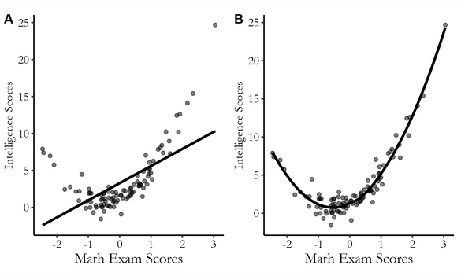

# Regressão Linear Simples ($k = 1$)

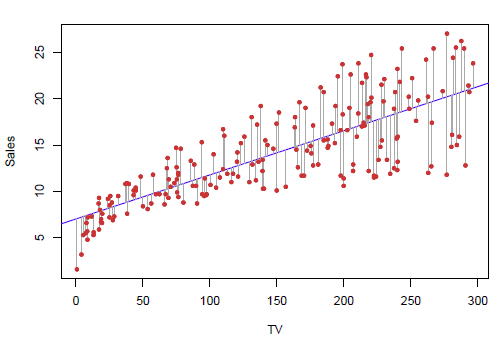

- Ajuste de MQ da regressão de `Sales` contra `Tv`
- Neste caso, o modelo linear captura a essência do relação, embora seja um pouco deficiente nos dados iniciais (esquerda do gráfico).

# Regressão Linear Múltipla ($k = 2$)

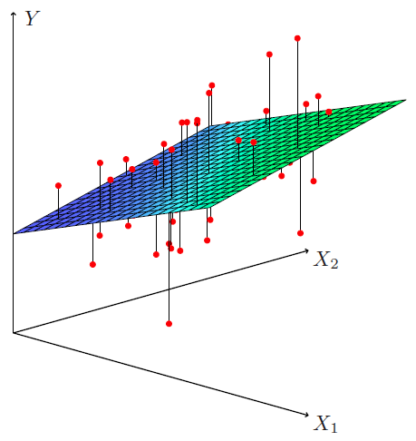

# Modelos de Regressão: Esperança Condicional

Regressão = Valor Esperado Condicional:

$$\begin{align*}
Y_{i} &= \beta_0 + \beta_1 X_{1} + \ldots +
\beta_p X_{p} + \epsilon_{i} \\
\epsilon_i &\sim N(0,\sigma^2) \\
E(Y_{i}|X_{1}\ldots X_{p}) &= E(\beta_0 + \beta_1 X_{1} + \ldots +
\beta_p X_{p} + \epsilon_{i}) \\
E(Y_{i}|X_{1}\ldots X_{p}) &= \hat{Y}_{i} =\hat{\beta}_o +
\hat{\beta_1} X_{1} +
\ldots + \hat{\beta_p} X_{p} \\
\hat{\epsilon}_{i} &= Y_{i} - \hat{Y}_{i} \sim N(0,\sigma^2)
\end{align*}$$

$\epsilon$ = erro

$\hat{\epsilon}$ = resíduo

# Modelos de Regressão: Esperança Condicional

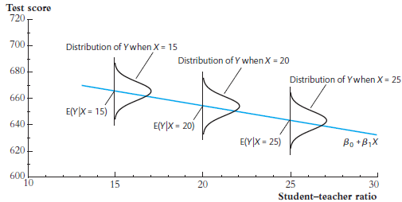

# Regressão Múltipla: Álgebra Matricial

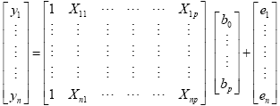

$$Y = X\beta + \epsilon$$

# Aplicações:

- Regressão Linear Simples:
  - Como o retorno de ativos varia com seu nível de risco de mercado (CAPM)
  - Mensuração da relação de longo prazo entre preços de ações e dividendos
  - Estimação da razão ótima de hedge
  - …
- Regresão Linear Múltipla:
  - Modelos Hedônicos de Precificação de Casas
  - Modelos Fatoriais (APT)
  - Estimativa de Custos
  - …

# Estimação dos Parâmetros por Mínimos Quadrados Ordinários

Método dos Mínimos Quadrados Ordinários:

Pelo método dos MQO, desejamos encontrar a equação da reta/plano que melhor se ``ajusta’’ aos dados. Isto implica em encontrar estimadores de $\beta_1,\beta_2,\ldots,\beta_p$ que minimizam a soma de quadrado dos resíduos:

$$\begin{align*}
\hat{\epsilon_i} &= y_i - \hat{y_i} \\
\sum \hat{\epsilon_i}^2 &= \sum (y_i - \hat{y_i})^2 \\
Min & \sum_{i=1}^{n} (y_i - \beta_0 - \beta_1 X_{i1} - \beta_2
X_{i2} - \ldots - \beta_p X_{ip})^2 \\
Min & \,\, \hat{\epsilon_i}^{t} \hat{\epsilon_i} = (X\hat{\beta} -
Y)^t(X\hat{\beta} - Y)
\end{align*}$$

# Geometria dos Mínimos Quadrados Ordinários

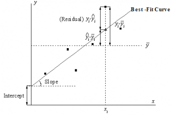

# Estimadores de MQO dos parâmetros

Regressão Simples:

$$\begin{align*}
\hat{\beta_1} &= \frac{\sum(y_i - \bar{y})(x_i - \bar{x})}{\sum (x_i
- \bar{x})^2} \\
\hat{\beta_0} &= \bar{y} - \hat{\beta}\bar{x}
\end{align*}$$

Regressão Múltipla - Matrizes:

$$\begin{equation*}
\hat{\beta} =
\begin{bmatrix}
\hat{\beta_0} \\
\hat{\beta_1} \\
\vdots
\hat{\beta_p}
\end{bmatrix}
=
(X'X)^{-1}X'Y
\end{equation*}$$

# Modelo Clássico de Regressão Linear: Hipóteses

| Hipótese | Interpretação |
| --- | --- |
| H1. $E(\epsilon_i\|X_i) = 0$ | erros tem média 0 |
| H2. $V(\epsilon_i\|X_i) = \sigma^2 < \infty$ | variância finita e constante |
| H3. $Cov(\epsilon_i,x_i) = 0$ | Não há correlação entre $\epsilon_i$ e $x_i$ |
| H4. $Cov(\epsilon_i,\epsilon_i) = 0$ | erros não são linearmente correlacionados |
| H5: $\epsilon_i \sim N(0,\sigma^2)$ | erros tem distribuição aprox. normal. |

# Propriedades dos Estimadores de MQO

- **H1**, **H2**, **H3** e **H4**
  - Garantem que os estimadores de MQO são os **melhores estimadores lineares não viesados**, segundo o [Teorema de Gauss-Markov](https://en.wikipedia.org/wiki/Gauss%E2%80%93Markov_theorem).
- **H5**
  - Necessária para fazermos inferências (testes de hipóteses, intervalos de confiança, intervalos de previsão) sobre os parâmetros do modelo  
    $(\beta_0,\beta_1,\ldots,\beta_p)$

# Propriedades dos Estimadores ($\hat{\beta}$) de MQO

- **Consistentes**
  - Os estimadores de MQO ($\hat{\beta}$) são consistentes. Ou seja, as estimativas convergirão para seus valores verdadeiros (populaciconais) à medida que o tamanho da amostra aumenta.
- **Não-Viesados**
  - Os estimadores de ($\hat{\beta}$) são não-viesados. Isto é, $E(\hat{\beta}) = \beta$. Assim, em média, o valor estimado será igual aos valores verdadeiros.
- **Eficientes**
  - Um estimador $\hat{\beta}$ de um parâmetro populacional $\beta$ é eficiente, se é não-viesado e nenhum outro estimador não-viesado tem variância inferior.

# Propriedades dos Estimadores ($\hat{\beta}$) de MQO

- Não-Viesados e Eficientes:

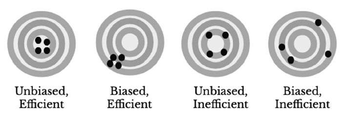

# Precisão e Erros-Padrão

- Qualquer conjunto de estimativas de regressão são específicos para a amostra usada em sua estimativa.
- Como utilizamos apenas uma amostra da população possível, cometemos erros nas estimativas, temos incerteza.
- Precisamos de medidas da precisão da regressão ($\sqrt{\hat{\sigma}^2}$) e das estimativas dos parâmetros $V(\hat{\beta})$.

# Estimador da Precisão do Modelo ($\sqrt{\hat{\sigma}^2}$)

- Dadas **H1**, **H2**, **H3** e **H4**, um estimador não viesado da variância ou do **erro padrão** da regressão é:

$$\begin{align*}
\sqrt{\hat{\sigma}^2} &= \frac{1}{n-k} \sum_{i=1}^{n} (Y_i -
\hat{Y}_i)^2 \\
\sqrt{\hat{\sigma}^2} &= \sqrt{\frac{(Y - X\hat{\beta})'(Y -
X\hat{\beta})}{n - k}}
\end{align*}$$

# Estimador da Precisão dos Parâmetros ($V(\hat{\beta})$)

Estimador da Matriz de Variância-Covariância dos Parâmetros:

$$V(\hat{\beta}) = \hat{\sigma}^2 (X'X)^{-1} = \hat{\sigma}^2
\begin{bmatrix}
V(\hat{\beta_0}) & & \\
COV(\hat{\beta_0},\hat{\beta_1}) &
V(\hat{\beta_1}) & \\
COV(\hat{\beta_0},\hat{\beta_2}) &
COV(\hat{\beta_1},\hat{\beta_2}) & V(\hat{\beta_2})
\end{bmatrix}$$

- Estimador do erro-padrão dos parâmetros:

$$EP(\hat{\beta}) = \sqrt{V(\hat{\beta})} = \hat{\sigma}^2(X^{t}X)^{-1}$$

# Estimador da Precisão dos Parâmetros ($V(\hat{\beta}$)

- Esses erros padrão são usados para calcular **intervalos de confiança**. A forma geral dos intervalos para as estimativas dos parâmetros é:

$$\hat{\beta_1} \pm 2 \times EP(\hat{\beta_1})$$

# Inferência Estatística para o Modelo Clássico de Regressão Linear

# Estimação de Modelo de Regressão em R

# Inferência Estatística

- Em geral, queremos fazer inferências sobre os parâmetros populacionais ($\beta$) a partir das estimativas destes parâmetros obtidas a partir das amostras ($\hat{\beta}$).
- Como vimos, podemos usar as informações da amostra para fazer inferências sobre a população.
- Os principais procedimentos de inferência estatística para modelos de regressão são:
  - intervalos de confiança para os parâmetros $\beta$
  - Testes de Hipóteses (ou de significância) para os parâmetros $\beta$]
  - intervalos de predição para $y_0$

# Intervalos de Confiança (para os parâmetros $\beta$)

- As estimativas dos erros-padrão da regressão e dos parâmetros são usadas para obtermos estimativas de **intervalos de confiança** para os parâmetros $\beta$].
- A forma geral dos intervalos de confiança para as estimativas dos parâmetros, com 95% de confiança é:

$$\begin{align*}
\hat{\beta_1} &\pm 2 \times EP(\hat{\beta_1}) \\
(\hat{\beta_1} - 2 \times EP(\hat{\beta_1})&, \,\,\hat{\beta_1} + 2
\times EP(\hat{\beta_1}))
\end{align*}$$

# Intervalos de Predição para $y_0$

$$\hat{y}_0 = \hat{\beta_0} + \hat{\beta_1}x_0$$

- Para um modelo de regressão linear simples, um IP para $y_0$, temos:

$$\begin{align*}
\hat{y}_0 &\pm t_{c} EP(f) \\
Ep(f) &= \sqrt{Var(\hat{y}_0 - y_0)} = \hat{\sigma}_{0}^2 \Bigl(1 +
\frac{1}{n} \frac{(x_0 - \bar{x})^2}{\sum (x_i - \bar{x})^2} \Bigr)
\end{align*}$$

# Testes de Hipóteses/Significância

- O teste de hipótese mais comum envolve testar as seguintes hipóteses:
  - $H_0$: Não há evidência de relação entre $X$ e $Y$
  - $H_A$: Há evidência de relação entre $X$ e $Y$
- Matematicamente, isso corresponde a testar:
  - $H_0: \beta_1 = 0$
  - $H_0: \beta_1 \neq 0$
- Pois se $\beta_1 = 0$, então o modelo de regressão linear simples torna-se $Y = \beta_0 + \epsilon$, e não relação entre $X$ e $Y$.

# Testes de Hipóteses/Significância: Teste $F$

**Teste F**: Testa se todas as estimativas dos parâmetros são iguais a zero.

$$\begin{align*}
H_0:\,\, & \beta_0 = \beta_1 = \ldots = \beta_p = 0 \\
H_A:\,\, & \text{Pelo menos um} \,\, \beta_p \neq 0 \\
F &= \Biggl(\frac{SQ_{total} - SQ_{residuo}}{SQ_{residuo}}\Biggr)
\frac{n - p}{p - 1} \sim F_{(q,n-(p+1))}
\end{align*}$$

- **Se valor-p** $<$ **0.05** -> Pelo menos uma estimativa de um parâmetro é estatisticamente diferente de zero
- **Se valor-p** $>$ **0.05** -> Nenhuma estimativa de parâmetro é estatisticamente diferente de zero
- O teste $F$ é um instrumento para avaliar a significância global do modelo.

# Testes de Hipóteses/Significância: Teste $t$

- Teste t: Testa se cada estimativa é diferentes de zero:

$$\begin{align*}
H_0:\,\, & \beta_p = 0 \\
H_A:\,\, & \beta_p \neq 0 \\
t & = \frac{\hat{\beta} - 0}{EP(\hat{\beta})} \sim
t_{(n-p,\alpha)}
\end{align*}$$

- Usando um software estatístico, é fácil calcular a probabilidade de observar um valor igual o maior que $|t|$, ou seja, o **valor-p**.
- **Se valor-p** $<$ **0.05** -> A estimativa **é** estatisticamente diferente de zero.
- **Se valor-p** $>$ **0.05** -> A estimativa **não é** estatisticamente diferente de zero.

# Testes de Hipóteses/Significância em R

# Testando Múltiplas Hipóteses: Teste$-F$

- Usamos o teste$-t$ para testar hipóteses únicas, ou seja, hipóteses envolvendo apenas um parâmetro. Mas e se quisermos testar mais de um parâmetro **simultaneamente**?
- Fazemos isso usando o Teste$-F$. O Teste$-F$ envolve estimar 2 regressões:
  - Uma regressão **irrestrita**
  - Uma regressão **restrita**
- Considere o seguinte modelo de regressão múltipla:

$$Y_{i} = \beta_0 + \beta_1 X_{1} + \beta_2 X_{2} + \beta_3 X_{3} +
\epsilon_{i}$$
- E que desejamos testar $H_0:\,\beta_2 + \beta_3 = 1$ ou $H_0:\, \beta_2 = 1$

# Testando Múltiplas Hipóteses: Teste$-F$

- a regressão irrestrita é:

$$Y_{i} = \beta_0 + \beta_1 X_{1} + \beta_2 X_{2} + \beta_3 X_{3} +
\epsilon_{i}$$
- a regressão restrita é:

$$\begin{align*}
Y_{i} &= \beta_0 + \beta_1 X_{1} + \beta_2 X_{2} + \beta_3 X_{3} +
\epsilon_{i} \,\, sujeito\,\,a \quad (\beta_2 + \beta_3 = 1) \\
Y_{i} &= \beta_0 + \beta_1 X_{1} + \beta_2 X_{2} + (1-\beta_2) X_{3}
+ \epsilon_{i} \\
Y_{i} &= \beta_0 + \beta_1 X_{1} + \beta_2 X_{2} + X_{3} - \beta_2
X_{3} + \epsilon_{i} \\
Y_{i} - X_{3} &= \beta_0 + \beta_1 X_{1} + \beta_2 (X_{2} - X_{3})
+ \epsilon_{i} \\
\end{align*}$$

# Testando Múltiplas Hipóteses: Teste$-F$

- Estatística de Teste e Distribuição:

$$F_{calc} = \Biggl(\frac{SQR_{restrito} -
SQR_{irrestrito}}{SQR_{irrestrito}}\Biggr) \frac{n - k}{m} \sim
F_{(m,n-k)}$$
- sendo: $n=$ n. de observações, $k=$ número de preditores na regressão irrestrita e $m = $ número de restrições.

- Rejetia-se $H0$ contendo a restrição se $F_{calc} > F_{(m,n-k)}$, ou de analisando-se o valor-p:
- **Se valor-p** $<$ **0.05** -> Os resultados fornecem evidência para  
  rejeitar a $H0$ contendo a restrição.
- **Se valor-p** $>$ **0.05** -> OS resultados fornecem evidência para não rejeitar a $H0$ contendo a restrição.

# Testando Múltiplas Hipóteses: Teste$-F$

- Determinando o número de restrições em um teste$-F$:

| $H_0$ : Hipóteses | N. de Restrições ($m$) |
| --- | --- |
| $H_0:\,\beta_2 + \beta_3 = 1$ | 1 |
| $H_0:$ $\beta_2 = 1$ e $\beta_3 = -1$ | 2 |
| $H_0:$ $\beta_1 = 0$, $\beta_2 = 0$ e $\beta_4 = 0$ | 3 |

# Regressão: Diferentes Abordagens

# Statistical Modelling: The Two Cultures

Abordagem: **Ciência dos Dados/Aprendizagem de Máquina**:

Dadas as estimativas $\hat{\beta}_0, \hat{\beta}_1,\ldots,\hat{\beta}_p$ o foco está em obter previsões ($\hat{y_i}$). Para modelos de regressão linear, pela fórmula:

$$\hat{y}_0 = \hat{\beta}_0 + \hat{\beta}_1 x_1 + \ldots,\hat{\beta}_p x_p$$

Abordagem: **Científica Tradicional**

Em geral, tem-se um modelo que tenta descrever como $X$ $\rightarrow$ $Y$. Na cultura científica tradicional, o intersse em geral está nas estimativas $\hat{\beta}_0, \hat{\beta}_1,\ldots,\hat{\beta}_p$. Exemplo: CAPM.

$$E(R_{i})=R_{f}+\beta _{im}(E(R_{m})-R_{f})$$

# Avaliação da Acurácia Explicativa

- $R^2$ = coeficiente de determinação

$$R^2 = \frac{\sum_{i = 1}^{n} (y_{i} - \bar{y})^2 - \sum_{i = 1}^{n}
(y_{i} - \hat{y})^2}{\sum_{i = 1}^{n} (y_{i} - \bar{y})^2} = \frac{SQT -
SQR}{SQT}$$

- **Interpretação:** $R^2$ mede a porcentagem da variação total dos dados ($SQT$) que é explicada pelo modelo ($SQT - SQR$).
- $R_{ajustado}^2$: Coeficiente de Determinação Ajustado

$$R^2 = 1 - \Bigl[ \frac{n - 1}{n - k} (1 - R^2)\Bigr]$$

- $R_{ajustado}^2$ é preferível a $R^2$

# Avaliação da Acurácia Preditiva

- Root-Mean-Square Error:

$${RMSE} ={\sqrt {\frac {\sum _{t=1}^{n}({\hat {y}}_{i}-y_{i})^{2}}{n}}}$$

- Mean Absolute Error

$$MAE = \frac{\sum_{i=1}^{n}|{\hat {y}}_{i}-y_{i}|}{n}$$

# Interpretação das Estimativas dos Parâmetros

### Interpretação do Intercepto ($\beta_0$)

- $\hat{b}_0$: Estimativa de $y$ quado as variáveis preditoras são iguais a zer, $X = 0$.
- $\hat{b}_0$: É preciso cuidado na interpretação (principalmente quando há poucas ou nenhuma observação próxima ao eixo $y$, veja fig.). Nem sempre a estimativa faz sentido ou e em diversos casos, não há interesse nesta estimativa.

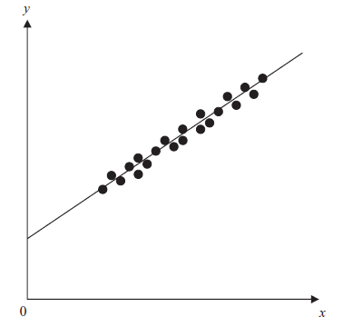

# $X$ Numéricos: Interpretação das Estimativas dos Parâmetros

- Interpretação de $\hat{\beta}$:

$$\frac{\partial \hat{y_{i}}}{\partial X_{i}} = \hat{\beta_i}$$

mensura o efeito médio sobre $Y$ do aumento de uma unidade em $X$, mantendo todas as outras preditoras $X$ constantes.

# $X$ binária: Interpretação dos Estimadores

Variável Binária ou *dummy*

$$x_i =
\begin{cases}
1 & \text{se i-ésima pessoa é mulher}, \\
0 & \text{se i-ésima pessoa é homem}
\end{cases}$$

Modelo resultante:

$$y_i = \beta_0 + \beta_1\ x_i + \epsilon_i =
\begin{cases}
\beta_0 + \beta_1 + \epsilon_i & \text{se i-ésima pessoa é
mulher},\\
\beta_0 + \epsilon_i & \text{se i-ésima pessoa é homem}
\end{cases}$$

**Interpretação**: $\beta_1$ é a diferença média em $y_i$ entre o nível para o qual $x_i = 0$ (o nível de referência) e a categoria para a qual $x_i = 1$ (o nível de comparação).

# $X$ Categórica: Interpretação dos Estimadores

- Podemos lidar com variáveis categóricas contendo mais de dois níveos, basta atribuir a cada uma das categorias sua própria variável binária:
- Com variáveis com mais de duas categorias, as estimativas dos parâmetros devem ser interpretadas em relação a uma categoria que deve não pode ser incluída no modelo, chamada nível de referência.
- Com variáveis binárias, c mensura a diferença média em $y_i$ entre “1” e “0”. Com uma variável categórica e um nível de de referência, $\beta$ mede a diferença média entre um nível qualquer e o nível de referência.

# $X$ Categórica: Interpretação dos Estimadores

- Considere que a França é o nível de referência escolhido para a seguinte regressão $renda = \beta_0 + \beta_1 Gambia+ \beta_2 NovaZealandia + ...$, Se estimamos o modelo e obtemos $\hat{\beta}_1 = 0.5$ e $\hat{\beta}_2 = 3$. Então a interpretação é de $\hat{\beta}_1$ e $\hat{\beta}_2$ é:
  - $\hat{\beta}_1$: renda média em Gâmbia é 0,5 superior à renda média na França
  - $\hat{\beta}_2$: renda média na Nova Zelância é 3 vezes superior à renda média na França
- e o rendimento médio na Nova Zelândia é 3 superior ao rendimento médio em França. Ambas as interpretações levam apenas coisas relativas à categoria de referência, não uma à outra

# Modelos com Interação: Interpretação dos Estimadores

Interpretação de $\hat{\beta}$ com interação:

$$\begin{aligned}
Y_i &= \beta_0 + \beta_1 X_1 + \beta_2 X_2 + \beta_3 (X_1\times
X_2), \\
sales &= \beta_0 + \beta_1\, TV + \beta_2\,radio + \beta_3\
newspaper +
\beta_3 (radio \times TV)
\end{aligned}$$
$$\begin{aligned}
\frac{\partial sales}{\partial TV} &= \beta_1 + \beta_3 radio, \\
\frac{\partial sales}{\partial radio} &= \beta_2 + \beta_3 TV
\end{aligned}$$

# Interpretação dos Estimadores de MQO dos Parâmetros

- Cenário ideal: $X$ não correlacionados
  - Dados balanceados
  - Cada coeficiente pode ser estimado e testado separadamente.
  - Interpretações como *um aumento de uma unidade em $X_j$ está associado a uma mudança de $\beta_j$ em $Y$, enquanto todas as outras variáveis permanecem fixas*, são possíveis.
- Problema: Se $X$ são correlacionadas (multicolinearidade)

Cuidado!:

**Alegações de causalidade devem ser evitadas com dados observacionais**. Para fazer jus, delineamentos e modelos específicos devem ser adotados.

# Transformação de Variáveis

### Logaritmos em modelos de regressão

- Em diversos casos, podemos obter melhores modelos utilizando transformaçãoes das variáveis $Y$ e/ou $X$.
- Por quê?
  - A primeira razão pode ser dar às variáveis propriedades estatísticas que funcionam melhor com a regressão. Por exemplo, podemos querer reduzir a assimetria.
  - A segunda razão para transformar uma variável é tentar obter uma relação linear entre as variáveis
  - A teoria que fundamenta o modelo sugere a transformação. Por exemplo, os diversos tipos de elasticidades definidos na teoria microeconômica tem uma clara relação com logaritmos.
- Tomar Logaritmos, ou realizar a transformação logarítmica das variáveis, é uma das transformações mais utilizadas e comuns.

# Logaritmos em modelos de regressão

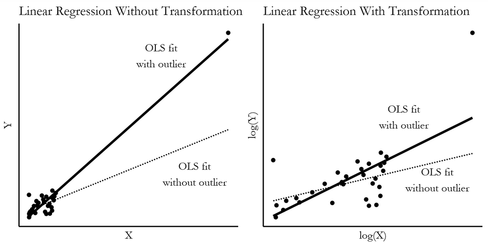

# Logaritmos em modelos de regressão

| Caso | Especificação | Interpretação de $\beta_1$ |
| --- | --- | --- |
| I | $Y_i = \beta_0 + \beta_1 \ln(X_1) + \epsilon_i$ | A variação de 1% em $X$ está associada a |
|  |  | uma variação média de 0,01$\beta_1$ em $Y_i$ |
| II | $\ln(Y_i) = \beta_0 + \beta_1 X_1 + \epsilon_i$ | A variação de 1 unidade em $X$ está associada a |
|  |  | uma variação média de 100$\beta_1$% em $Y_i$ |
| III | $\ln(Y_i) = \beta_0 + \beta_1 \ln(X_1) + \epsilon_i$ | A variação de 1% em $X$ está associada a |
|  |  | uma variação média de 100$\beta_1$ em $Y_i$ |

# Outras Transformações

- As seguintes transformações são alternativas a problemas com logaritmos. Em particular, temos que $\log(0)$ é indefinido.
- $\log(x + 1)$: não recomendável.
- $\sqrt{x}$: transformação raíz quadrada. Reduz um pouco o peso dos outliers, mas não tão bem como logaritmos
- $\ln(x + \sqrt{x^2+1})$: função seno hiperbólica inversa. Reduz o peso dos outliers de forma similar aos logaritmos, sendo definida para zero ($asinh(0) = 0$). **É a mais recomendada para dados com distribuição assimétrica e zeros**.

# *Winsorizing*

- Esta transformação não trata de assimetria ou linearização de um modelo, mas com *outliers* (valores extremos).
- *Winsorizing*, especialmente popular em finanças, é o processo de tomar alguns dados e reduzir os extremos. Simplesmente tomamos todos os valores que estão longe o suficiente do centro e os reduzimoz em direção ao centro.
- Para **Winsorizar** os top $X$ % dos dados superiores, tomamos todas as observações acima do percentil $p_i$ e as substituimos pelo percentil $p_i$.
- Por exemplo, se tivéssemos 100 observações de 1 a 100. Para Winsorizar os 5% dos ddados superiores e inferiores, mantemos as observações 6-95 e, em seguida, tomamos as observações 1, 2, 3, 4 e 5 e substituimoss por 6, e tomamos as observações 96, 97, 98, 99 e 100 oe substituimos por 95.

# *Winsorizing*

- Este é um método força bruta para lidar com outliers, mas tende a funcionar. Deixa a maioria dos dados intocados, o que é bom se você acha que o verdadeiro relacionamento é realmente linear, mas não quer que seu modelo seja muito influenciado por valores discrepantes.

# Padronização

- Não melhora as propriedades estatísticas do modelo. Não lida com assimetria, *outliers* ou linearização.
- Esta é a transformação de padronizar uma variável subtraindo sua média e dividindo por seu desvio padrão $(x - \bar{x})/s_x$.
- Por que usar esta transformação? Porque pode tornar o modelo mais fácil de interpretar em alguns casos.
- se padronizarmos uma variável, a interpretação de $\hat{\beta}$ será então “*aumento de um desvio padrão em* $X$…”, o que pode ser mais fácil de avaliar em alguns casos.

# Etapas Típicas: Análise de Regressão

1. Prepação dos Dados
2. Análise Exploratória dos Dados
3. Estimação dos parâmetros do modelo completo.
4. Diagnóstico do modelo completo
5. Se necessário -> seleção de variáveis/Modelos -> diagnóstico do modelo selecionado
6. Diagnóstico do Modelo Final. Se o modelo final:
   - for adequado -> análise das estimativas dos parâmetros e/ou previsão e comunicação dos resultados
   - se não, iniciar novamente o ciclo e tentar outros modelos.

# Análise Exploratória dos Dados

- Antes de qualquer análise, os dados deve ser inspecionados sobre:
- Erros nos dados
- Dados faltantes
- Valores Extremos
- Padrões inesperados
- $\vdots$

# Estimação de Parâmetros e Inferência em R

```r
# A Funcao lm() estima o modelo
modelo = lm(Y ~ X1 + X2 + X3 + ..., data = data frame)

# A funcao summary() exibe os resultados
summary(modelo)
```

# Estimação de Parâmetros e Inferência no R

# Estimação de Parâmetros e Inferência em R

- Estimativa de **Intervalos de Confiança** para os Parâmetros

```r
# estimativas de IC para os parametros
confint(modelo,level = 0.95)
```

- Atenção!:

A hipótese de normalidade dos resíduos é importante para a qualidade das estimativas destes intervalos

# Estimação de Parâmetros e Inferência em R

Estimação de **Intervalos de Previsão** no R

```r
## predict = estimativas pontuais e intervalos de previsao
## para Y
previsoes <- predict(modelo, dados_teste, interval = "prediction")
```

**Atenção!:**

A hipótese de normalidade dos resíduos é importante para a qualidade das estimativas destes intervalos.

# Diagnósticos de Modelos de Regressão

[output not shown]

# Diagnósticos

| Diagnóstico | Teste |
| --- | --- |
| Outliers | Gráficos e estatísticas |
| Multicolinearidade em $X$ | VIF |

# Testes de Especificação

### Teste RESET: *Regression Specification Error Test*

- **Teste RESET** Teste do erro de especificação da regressão. Testa para variáveis omitidas (**endogeneidade**) e formas funcionais incorretas (**não-linearidade**).
- **Procedimento**: Suponha que tenhamos especificado e estimado o modelo:

$$\begin{align*}
y_i &= \beta_1 + \beta_2 x_{i2} + \beta_3 x_{i3} + \epsilon_i
\\
\hat{y}_i &= \hat{\beta}_1 + \hat{\beta}_2 x_{i2} + \hat{\beta}_3
x_{i3}
\end{align*}$$

Considere o seguinte modelo artificial:

$$y_i = \beta_1 + \beta_2 x_{i2} + \beta_3 x_{i3} + \gamma_1 \hat{y}_i^2 +
\gamma_2 \hat{y}_i^3 + \epsilon_i$$

# Teste RESET: *Regression Specification Error Test*

$$y_i = \beta_1 + \beta_2 x_{i2} + \beta_3 x_{i3} + \gamma_1 \hat{y}_i^2 +
\gamma_2 \hat{y}_i^3 + \epsilon_i$$

- Testamos $H_0$: $\gamma_1 = \gamma_2 = 0$ contra $H_A$: $\gamma_1 \neq 0$ ou $\gamma_2 \neq 0$.
- Note que $\hat{y}_i^2$ e $\hat{y}_i^3$ são funções polinomiais de $x_{i2}$ e $x_{i3}$, Assim, se o modelo original não é a forma funciconal correta, a aproximação polinomial que inclui $\hat{y}_i^2$ e $\hat{y}_i^3$ pode melhorar significativamente o ajusde do modelo, e esse fato será detecatado por valores não nulos de $\gamma_1$ e $\gamma_2$.
- Além disso, se tivermos omitido variáveis, e essas variáveis forem correlacionadas com $x_{i2}$ e $x_{i3}$, então, alguns dos seus efeitos podem ser detectados pela inclusão dos termos $\hat{y}_i^2$ e $\hat{y}_i^3$.

# Teste RESET: *Regression Specification Error Test*

- **Filosofia geral do teste**: se podemos melhorar significativamente o modelo pela inclusão artificial de potências das predições do modelo, então há evidências de que o modelo original é inadequado, seja devido a **não linearidade** ou a **endogeneidade** $(Cov(\epsilon_i,x_i) \neq 0)$.
- **Regra de Decisão** Valores-p maiores que 0.05 (5%) implicam que a $H_0$ de que o modelo linear é uma especificação adequada. Ou seja, a $H_0$ não deve ser rejeitada.

```r
# Teste RESET em R
library(lmtest)

# endogeneidade
resettest(modelo, power = 2:3, type = "fitted")

# nao-linearidade
resettest(modelo, power = 2:3, type = "regressor")
```

# Seleção Automatizada de Variáveis Preditoras

- Procedimentos de **seleção de variáaveis** são algoritmos para selecionar um “melhor”modelo a partir de vários modelos/variáveis possíveis
- Muitas vezes não há um modelo teórico que explique determinado fenômeno, assim, tenta-se construir um modelo **empírico**. Nestes casos, pode-se pensar na inclusão de muitas variáveis
- Compromisso entre **Qualidade do Ajuste** $\times$ **Complexidade do Modelo**.
- Na abordagem de Ciência dos Dados/Machine Learning, este procedimento é denominado **feature engineering**.

# Seleção Automatizada de Variáveis Preditoras

- **Regressão Stepwise**: Backward
  - É um método para estimar diversos modelos de regressão e selecionar as variáveis preditoras que devem ser mantidas. O procedimento envolve, a partir do modelo contendo todas as variáveis preditoras ($X$), retirar cada uma das variáveis preditorasdo modelo (stepwise backward), e selecionar as que devem ser mantidas de acordo com algum critério, o mais usado é a manter as variáveis que reduzem o Critério de Informação de Akaike (AIC)

# Seleção Automatizada de Variáveis Preditoras

- O **Critério de Informação de Akaike (AIC)** é uma medida relativa da qualidade de um modelo estatístico. Isto é, dado um conjunto de modelos para os dados, o AIC estima a qualidade de cada modelo, em relação a cada um dos outros modelos possíveis.
- O AIC tem como base a **Teoria da Informação**, fornece uma estimativa relativa da **informação perdida** quando um determinado modelo é usado para representar o processo que gera os dados.

$$AIC = 2K - 2\ln(L)$$

# Seleção Automatizada de Variáveis Preditoras

- Regressão Stepwise em R:
- Quanto menor o AIC, menor a “informação perdida” pelo modelo em questão. Assim, ao selecionar modelos, escolhemos aquele com o menor AIC.

```r
## Regressao Stepwise
modelo_final = stepAIC(mcompleto, direction = "backward")
summary(modelo_final)
```

# Testes dos Resíduos

# Teste de Breusch-Pagan

Teste da constância da variância dos resíduos:

**Teste de Breusch-Pagan** Testa a $H0$: os resíduos tem variância homogênea,

**Regra de Decisão** Valores-p maiores que 0.05 (5%) implicam que a $H_0$ de que os resíduos tem variância homogênea não deve ser rejeitada.

```r
# Teste de Breusch-Pagan no R
library(lmtest)
bptest(modelo)
```

# Teste de Jarque-Bera

Teste de Normalidade dos Resíduos:

- **Teste de Jarque-Bera** Testa a $H0$ os resíduos tem distribuição aproximadamente normal. O teste baseia-se na comparação dos coeficientes de assimetria e de curtose dos dados com os de uma distribuição normal.
- **Regra de Decisão** Valores-p maiores que 0.05 (5%) implicam que a $H_0$ de que os resíduos tem distribuição aproximadamente normal não deve ser rejeitada.

```r
# Teste de Jarque-Bera no R
library(DescTools)
JarqueBeraTest(modelo_step$residuals, robust = TRUE))
```

# Teste de Durbin-Watson

Teste Autocorrelação temporal dos Resíduos:

- Aplicado quando $Y_t$ e $X_t$ são **séries temporais**.
- **Teste de Durbin-Watson**: Testa a $H0$ de ausência de autocorrelação no lag 1 dos resíduos. Se $e_t$ é o resíduo dado por $e_t = \rho e_{t-1} + v_t$, testa H0: $\rho = 0$.
- **Regra de Decisão**: Valores-p maiores que 0.05 (5%) implicam que a $H_0$ de que os resíduos não são autocorrelacionados (no lag 1) não deve ser rejeitada.

```r
# Teste de Durbin-Watson no R
library(car)
durbinWatsonTest(modelo)
```

# Multicolinearidade

- Dizemos que há multicolinearidade nas variáveis preditoras ($X$’s) quando duas ou mais variáveis $X$ apresentam forte correlação entre si.
- Efeito da multicolinearidade:
  - Quando a correlação entre os $X$ é forte, não conseguimos separar os efeitos ($\beta$) das variáveis, isto reflete-se em:
  - A variância (Erros-padrão) de todas as estimativas dos parâmetros tende a aumentar, às vezes dramaticamente, o que pode tornar as stimativas dos parâmetros **não significativas**, com sinal e magnitude **sem sentido**.
  - As interpretações tornam-se perigosas - quando $X_j$ muda, tudo muda.

# Multicolinearidade: Fator de Inflação da Variância

O vif para uma única variável $X$ é obtido usando o $R^2$ da regressão da variável contra todas as outras variáveis $X$’s:

$$vif_j = \frac{1}{1 - R_{j}^2}$$

$|vif| > 5$ e $|vif| > 10$ são os critérios mais comuns para dizer se uma variável está causando multicolinearidade, ou não.

```r
# VIF no R
library(car)
vif(modelo)
```

# Multicolinearidade: Correções

- Correções para multicolinearidade:
  - Retirar variáveis redundantes ($|vif| > 10$)
  - Coletar mais dados
  - Se possível, tentar uma nova especificação do modelo

# Observações Influentes: Pontos de Alavancagem e Outliers

### Pontos de Alavancagem e Outliers

- **Observações Influentes**: Observações que afetam fortemente os resultados de Modelos de Regressão Linear.
  - **Outliers**: são observações que “puxam” a reta de regressão (ou superfície) em uma direção ou outra. Valores da variável resposta $y$ relativamente distantes dos outros valores $y$.
  - **Pontos de Alta Alavancagem**: Pontos de alta alavancagem são observações discrepantes ou distantes de outros valores das variáveis explicativas $x$. Pontos de Alavancagem podem ser ou não outliers.
  - **Obs**. O termo alavancagem refere-se à distância do valor de uma observação na(s) variável(is) explicativa(s) $x$ do valor médio da(s) variável(is) explicativa(s). As alavancas podem denotar pontos muito próximos ou muito distantes da(s) média(s)).

# Pontos de Alavancagem e Outliers

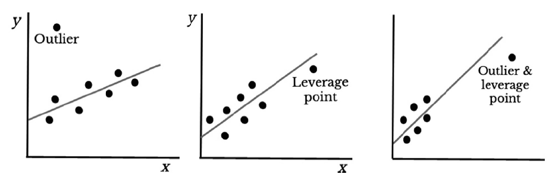

# Detectando Observações Influentes

- Há vários métodos para detecar observações influentes: Distância de Cook, `DFFITS`, entre outras.
- Distância de Cook:

$$\begin{align*}
D &= \frac{(y_i - \hat{y}_i)^2}{(k + 1)EQM} \times \frac {h_{ii}}{(1
- h_{ii}})^2 \\
H &= X(X^{t}X)^{-1} X^{t}
\end{align*}$$

- Critérios recomendados: Uma observação é influente se $D \geq 1.0$ e $D \geq 4/(n - k - 1)$.
- Os pontos de dados que atendem ou excedem esses limites devem ser examinados como observações influentes.

# Detectando Observações Influentes em R

```r
modelo <- lm(y ~ x1 + x2 + x3, data = data frame)

# funcao interna influence.measures()
obs_influentes <- influence.measures(modelo)

# quais observacoes sao influentes?
summary(obs_influentes)
```

- Exibe uma tabela mostrando distâncias de Cook, `DFBETAS` para cada variável do modelo, DFFITS, razões de covariância, e os elementos diagonais da matriz $H$. Os casos que são influentes em relação a qualquer uma dessas medidas são marcados com um asterisco.

# Pontos de Alavancagem e Outliers

- Observações influentes resultam de várias fontes:
  - Erros na codificação dos dados (sempre importante checar.);
  - Mas podem ser ocorrências naturais do fenômeno estudado.
- Possíveis Soluções:
  - Se a natureza de uma variável leva a valores extremos, uma solução comum é extrair esses valores tomando o logaritmo natural da variável, ou a transformação seno hipebólica inversa.
  - Antes de estimar um modelo, é sempre importante fazer uma análise exploratória de dados para visualizar as distribuições e avaliar se parece haver pontos de alta alavancagem e outliers Use gráficos de dispersão para examinar a associação entre as variáveis explicativas propostas e a variável resposta.
  - Em muitas situações, podemos identificar observações incomuns antes de estimar o modelo e propor soluções no início do processo de investigação.

# Pontos de Alavancagem e Outliers

[figure not shown]

# Diagnósticos Gráficos

### Gráfico dos Resíduos x Valores previstos

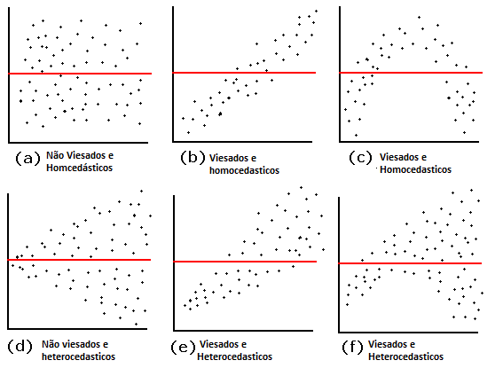

# Gráfico quantil-quantil normal

- Neste gráfico, podemos verificar:
- H5: $\epsilon_i \sim N(0,\sigma^2)$, ou seja, se os resíduos tem distribuição aproximadamente normal.

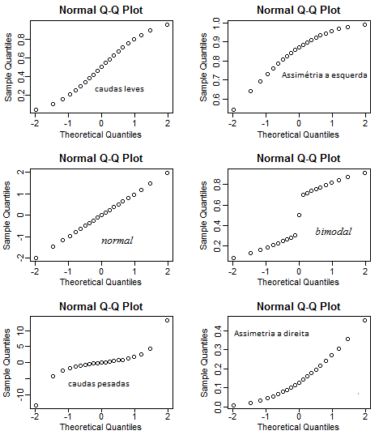

# Gráfico dos Resíduos Padronizados $\times$ Previstos

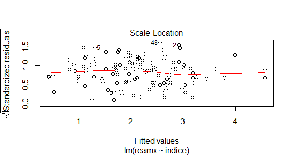

# Diagnóstico de Modelos de Regressão Linear

| **Problema** | **Teste** | **Consequências** | **Solução** |
| --- | --- | --- | --- |
| Não-linearidade | RESET | Pior cenário | Transf; Mod. Não Linear |
| Hetocedasticidade | Breusch- Pagan | Erros-padrões viesados | Calcular erros-padrões |
|  |  | Testes e IC Inválidos | robustos |
| Não | Jarque-Bera | Testes, IC, IP inválidos | MLG |
| normalidade |  |  | Modelos não-paramétricos |
|  |  |  | Modelos robustos |

# Diagnóstico de Modelos de Regressão Linear

| **Problema** | **Teste** | **Consequências** | **Solução** |
| --- | --- | --- | --- |
| Autocorrelação | Durbin-Watson | Erros-padrões viesados | Calcular Erros-padrões |
|  |  | Testes e IC inválidos | robustos |

# Referências

BROOKS, Chris.. **Introductory Econometrics for Finance**. 4 ed. Cambridge University Press, 2019. Capítulos: 3, 4 e 5.

WICHMANN, Robert; BROOKS, Chris **R Guide to Accompany Introductory Econometrics for Finance 4 edition**. 2019. Capítulos: 3, 4, 5, 6 e 7.